# Homework 06 – STAT 432

*Heta Patel (heta2). All code uses Python with the provided `breast-cancer-split.csv` to reproduce the R seed-432 split (398 training, 171 test observations).*

## Question 1: Compare KNN and Logistic Regression

### Setup and Standardisation

The breast-cancer data is loaded and split into 398 training and 171 test observations using the provided split file. Predictors are standardised using the training means and standard deviations; the same transformation is applied to the test set.

```
# Python
import numpy as np
import pandas as pd
from sklearn.linear_model import LogisticRegression
from sklearn.neighbors import KNeighborsClassifier
from sklearn.metrics import roc_curve, roc_auc_score
import matplotlib.pyplot as plt

data = pd.read_csv("data/breast-cancer.csv")
split = pd.read_csv("data/breast-cancer-split.csv")
train = data.loc[split["split"].eq("train")]
test  = data.loc[split["split"].eq("test")]
predictors = ["mean_radius", "mean_texture", "mean_smoothness"]

x_bar = train[predictors].mean()
s     = train[predictors].std(ddof=1)
X_train = ((train[predictors] - x_bar) / s).to_numpy()
X_test  = ((test[predictors]  - x_bar) / s).to_numpy()
y_train = train["y"].to_numpy()
y_test  = test["y"].to_numpy()
```

### Model Fitting and AUC

Logistic regression is fit with no penalty (`C=np.inf`), and KNN is fit for each *k* ∈ {5, 15, 25, 35, 45} with Euclidean distance and equal weights. Estimated probabilities for class 1 on the test set are used to compute ROC curves and AUC.

```
# Python
fit = LogisticRegression(C=np.inf, solver="lbfgs", fit_intercept=True,
                         tol=1e-10, max_iter=1000)
fit.fit(X_train, y_train)

k_values = [5, 15, 25, 35, 45]
model_names = ["Logistic regression"] + [f"KNN, k = {k}" for k in k_values]
p_test = np.empty((len(y_test), len(model_names)))
p_test[:, 0] = fit.predict_proba(X_test)[:, 1]
for m, k in enumerate(k_values):
    knn = KNeighborsClassifier(n_neighbors=k, weights="uniform",
                               metric="euclidean", algorithm="brute")
    knn.fit(X_train, y_train)
    p_test[:, m + 1] = knn.predict_proba(X_test)[:, 1]

auc_test = [roc_auc_score(y_test, p_test[:, m])
            for m in range(len(model_names))]
```

| Model | Test AUC |
| --- | --- |
| Logistic regression | 0.9746 |
| KNN, k = 5 | 0.9329 |
| KNN, k = 15 | 0.9480 |
| KNN, k = 25 | 0.9599 |
| KNN, k = 35 | 0.9727 |
| KNN, k = 45 | 0.9741 |

### ROC Curves

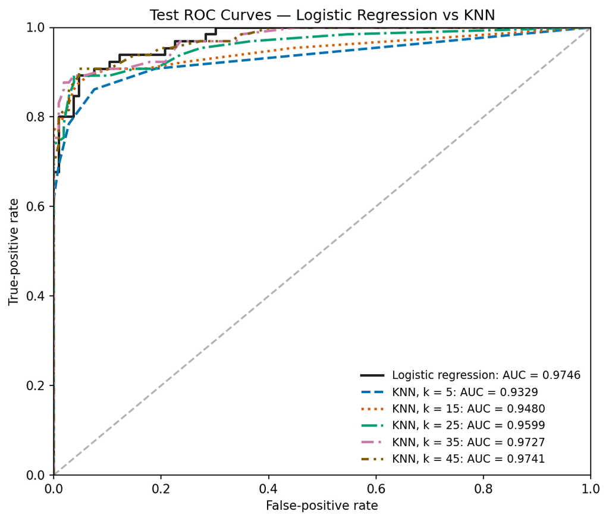

Figure 1. Test ROC curves for logistic regression and five KNN fits on 171 test observations.

### Model Selection

**I prefer logistic regression** for this split. Its test AUC of 0.9746 is the highest among the six models. As *k* decreases, KNN's test AUC drops, with *k* = 5 achieving only 0.9329. The larger neighbourhoods (*k* = 35, 45) nearly match logistic regression, suggesting the decision boundary is approximately linear in these three standardised features.

This comparison is on a single split. A small AUC difference does not establish that one method is universally better. AUC measures the quality of the probability ranking across all possible cutoffs, not classification accuracy at a single threshold. For a definitive comparison, one would use cross-validation within the training data to choose the method and *k*, then evaluate the winner on a held-out test set.

## Question 2: Training and Test ROC Curves

### Fitting and Evaluation

The same data split and standardisation are reused. KNN is fit for *k* ∈ {1, 3, 5, 10, 20}. For training predictions, each observation is included among its own *k* nearest neighbours (by passing `X_train` to `predict_proba`).

```
# Python
k_values = [1, 3, 5, 10, 20]
p_train = np.empty((len(y_train), len(k_values)))
p_test  = np.empty((len(y_test),  len(k_values)))
auc_train = np.empty(len(k_values))
auc_test  = np.empty(len(k_values))

for m, k in enumerate(k_values):
    knn = KNeighborsClassifier(n_neighbors=k, weights="uniform",
                               metric="euclidean", algorithm="brute")
    knn.fit(X_train, y_train)
    p_train[:, m] = knn.predict_proba(X_train)[:, 1]
    p_test[:, m]  = knn.predict_proba(X_test)[:, 1]
    auc_train[m]  = roc_auc_score(y_train, p_train[:, m])
    auc_test[m]   = roc_auc_score(y_test,  p_test[:, m])
```

| *k* | Training AUC | Test AUC | Gap |
| --- | --- | --- | --- |
| 1 | 1.0000 | 0.8764 | 0.1236 |
| 3 | 0.9905 | 0.9138 | 0.0768 |
| 5 | 0.9847 | 0.9329 | 0.0518 |
| 10 | 0.9862 | 0.9446 | 0.0415 |
| 20 | 0.9880 | 0.9586 | 0.0294 |

### ROC Panels

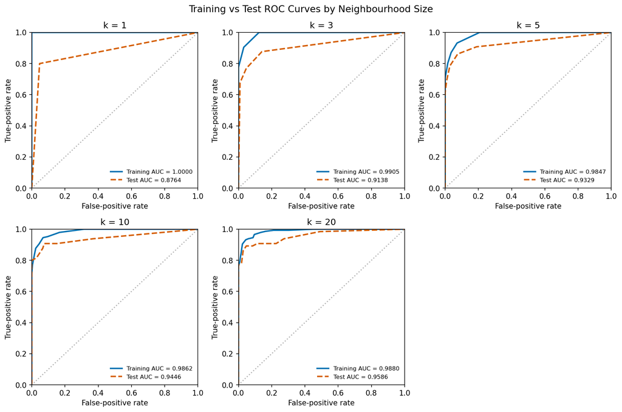

Figure 2. Training (solid blue) and test (dashed orange) ROC curves for each neighbourhood size. The *k* = 1 training curve has AUC = 1.

### Explanation

**What happens at *k* = 1.** When *k* = 1, each training observation is its own nearest neighbour, so the estimated probability equals the observed label (0 or 1). The training ROC curve therefore achieves AUC = 1.0000 by construction — every positive is ranked above every negative. However, the test AUC is only 0.8764, because a new observation's single nearest training neighbour may have a different label simply due to noise or local structure. The fitted probabilities take only the values 0 and 1, so the test ROC curve has a single nontrivial operating point, and AUC equals (sensitivity + specificity) / 2.

**How the gap changes with *k*.** As *k* increases from 1 to 20, the training-test AUC gap shrinks from 0.1236 to 0.0294. Larger neighbourhoods average over more training labels, reducing the variance of the estimated probabilities and making training performance a more realistic estimate of test performance. At the same time, test AUC generally improves because the smoother probability estimates rank observations more effectively.

**Why training performance may not reflect test performance.** Training AUC is evaluated on the same observations used to define the neighbourhoods. With small *k*, the model memorises individual labels, producing overly optimistic training metrics. Increasing *k* reduces each observation's influence on its own prediction, narrowing the optimism. However, if *k* becomes too large, averaging over distant observations can smooth away genuine local structure, harming both training and test performance. Neither the test AUC nor the training-test gap must change monotonically on any particular split.

## Question 3: Peer Evaluation of Homework 5

*The peer-evaluation question requires reviewing two other students' Homework 5 submissions via GitHub Issues. This review must be completed individually and cannot be answered by code generation. Please refer to the GitHub Issue assigned to my repository by **rqzhu-aide** for the specific reports to review.*

*All code is reproducible using the provided `breast-cancer-split.csv`, which records the R seed-432 split. The HTML file is self-contained.*